# SGD Clustering

Danielle Barnas

8/18/2022

# Clustering Analysis

## Load Libraries

```r
#options('repos' = c(options('repos')$repos, RSPM = "https://my-repo.com/all/latest"))

library(tidyverse)
library(curl) # pull data from url
library(here)
library(lubridate)
library(VarSelLCM) # LCM - cluster modeling
library(ggmap)
library(PNWColors)
library(tidytext) # arrange data in a facet_wrap
library(kableExtra) # create neat tables
library(ggrepel) # labeling
library(ggpmisc) # add R2 to figures
library(patchwork)

# API<-names(read_table(here("Data","API.txt")))
# register_google(key = API) ### uses my API in separate txt file

set.seed(7) # set the seed to get the same one every time
```

## Read in Data

```r
## Read in data

AugChemData<-read_csv(curl('https://raw.githubusercontent.com/njsilbiger/MooreaSGD_site-selection/main/Data/August2021/Allbiogeochemdata_QC.csv'))
turbAug<-read_csv(here("Data","Biogeochem","August2021","Turb_NC.csv"))
MarchChemData <- read_csv(curl('https://raw.githubusercontent.com/njsilbiger/MooreaSGD_site-selection/main/Data//March2022/CarbonateChemistry/pHProbe_Data_calculated_POcorrect.csv'))
turbMarch<-read_csv(here("Data","Biogeochem","March2022","Turb_NC.csv"))
```

## Clean Data for analysis

```r
## remove unnecessary/redundant turbinaria data to not include in cluster analysis
## add seasonal description
turbAug <- turbAug %>%
  select(CowTagID, del15N, N_percent) %>%
  mutate(Season = "Dry")

turbMarch <- turbMarch %>%
  select(CowTagID, del15N, N_percent) %>%
  mutate(Season = "Wet")

## combine turbinaria data
turb <- turbAug %>%
  full_join(turbMarch)
## Isolate gps coordinates to join with March data
gps <- AugChemData %>%
  select(CowTagID, lat, lon) %>%
  distinct()

## August
## There seems to be a contaminated nutrient sample for V2 Low tide on the 8/8/2021.  Remove this point
removeSite1 <- AugChemData %>%
  filter(CowTagID == "V2",
         Tide == " Low",
         Day_Night == "Day",
         Date == ymd("2021-08-08"))

removeSite2 <- AugChemData %>%
  filter(CowTagID == "C4",
         Tide =="Low",
         Day_Night == "Night",
         Date == ymd("2021-08-09"))

## Filter out redundant low tide day sample, first 'low tide' was super high
removeSite3 <- AugChemData %>%
  filter(Tide == "Low",
         Day_Night == "Day",
         Date == ymd("2021-08-06"))

AugChemData <- AugChemData %>%
  anti_join(removeSite1) %>%
  anti_join(removeSite2) %>%
  anti_join(removeSite3) %>%
  mutate(Season = "Dry") %>%  # add seasonal description
  # only keep Plate and Seep data
  filter(Plate_Seep %in% c("Plate", "Seep")) %>%  # ignores springs and well
  # remove unnecessary columns
  select(-c(Date,
            Time,
            DateTime,
            Plate_Seep,
            Top_Plate_ID,
            Bottom_Plate_ID,
            Jamie_Plate_ID,
            Temperature,
            MarineHumic_Like, Lignin_Like)) # Craig recommends to remove "because we don't hypothesize them to be orthogonal to any of the other fDOM we're using"
## Filter out unnecessary data not related to my sample locations
removeSiteMarch <- MarchChemData %>%
  filter(CowTagID %in% c("VSPRING", # sample locations unnecessary for my analysis
                         "VRC",
                         "CRC",
                         "CPIT",
                         "CPIT_Bottom",
                         "CSPRING_ROAD",
                         "CSPRING_BEACH",
                         "CSPRING_BEACH2"))

MarchChemData <- MarchChemData %>%
  anti_join(removeSiteMarch) %>%
  mutate(Season = "Wet") %>%  # add seasonal description
  select(-c(TempInSitu,
            Notes,
            SamplingTime)) %>%
  # add Location
  mutate(Location = if_else(str_detect(CowTagID, "^V") == T, "Varari", "Cabral")) %>%  # if CowTagID starts with V, label location as varari, else (if starts with C) label as Cabral
  left_join(gps)
## Join dataframes
AllChemData <- full_join(AugChemData, MarchChemData)
```

[output not shown]

```r
head(AllChemData)
```

```
## # A tibble: 6 x 21
##   Location   lat   lon CowTagID Tide  Day_Night Salinity    TA    pH
##   <chr>    <dbl> <dbl> <chr>    <chr> <chr>        <dbl> <dbl> <dbl>
## 1 Varari   -17.5 -150. V1       High  Day           36.4 2310.  8.06
## 2 Varari   -17.5 -150. V1       High  Night         36.4 2333.  8.03
## 3 Varari   -17.5 -150. V1       Low   Night         36.2 2339.  8.07
## 4 Varari   -17.5 -150. V1       Low   Day           36.5 2377.  8.01
## 5 Varari   -17.5 -150. V2       High  Day           36.4 2353.  8.05
## 6 Varari   -17.5 -150. V2       High  Night         36.4 2328.  8.02
## # ... with 12 more variables: Phosphate_umolL <dbl>, Silicate_umolL <dbl>,
## #   NN_umolL <dbl>, Ammonia_umolL <dbl>, M_C <dbl>, HIX <dbl>,
## #   VisibleHumidic_Like <dbl>, Tryptophan_Like <dbl>, Tyrosine_Like <dbl>,
## #   Season <chr>, Date <date>, SeepCode <chr>
```

## Histograms

- create a histogram to see distribution and transform whatever isn’t normal
- ggridges shows distribution of means vs raw data if I input the means (but raw data can help determine if I should use means or medians or max’s etc.)
- summarise, log10 what needs it, then standardize and center, then select important variables

Summarise: Range of parameters across sample times

```r
# Range of parameters
Full_data <- AllChemData %>%
  group_by(Location, CowTagID, Season) %>%
  # get parameter ranges across sampling periods by site and plate
  summarise_at(vars(Salinity:Tyrosine_Like), .funs = range, na.rm=T) %>% # returns two rows containing max and min value per CowTagID
  summarise_at(vars(Salinity:Tyrosine_Like), .funs = diff, na.rm=T) %>%  # returns difference between rows per CowTagID (yields range at each location)
  ungroup() %>%
  left_join(turb, by = c('CowTagID', 'Season'))  # join with turb


Full_data
```

```
## # A tibble: 84 x 17
##    Location CowTagID Season Salinity     TA     pH Phosphate_umolL
##    <chr>    <chr>    <chr>     <dbl>  <dbl>  <dbl>           <dbl>
##  1 Cabral   C1       Dry       0.270  50.0  0.198           0.1
##  2 Cabral   C1       Wet       0.290 209.   0.216           0.0137
##  3 Cabral   C10      Dry       0.200  60.7  0.157           0.07
##  4 Cabral   C10      Wet       0.130  38.2  0.174           0.0403
##  5 Cabral   C11      Dry       0.110  12.2  0.0811          0.07
##  6 Cabral   C11      Wet       0.200  75.1  0.199           0.0566
##  7 Cabral   C12      Dry       0.140   5.96 0.0707          0.1
##  8 Cabral   C12      Wet       0.130  73.8  0.145           0.0787
##  9 Cabral   C13      Dry       0.950  86.8  0.209           0.09
## 10 Cabral   C13      Wet       0.140 103.   0.270           0.0767
## # ... with 74 more rows, and 10 more variables: Silicate_umolL <dbl>,
## #   NN_umolL <dbl>, Ammonia_umolL <dbl>, M_C <dbl>, HIX <dbl>,
## #   VisibleHumidic_Like <dbl>, Tryptophan_Like <dbl>, Tyrosine_Like <dbl>,
## #   del15N <dbl>, N_percent <dbl>
```

## Check relationships to silicate

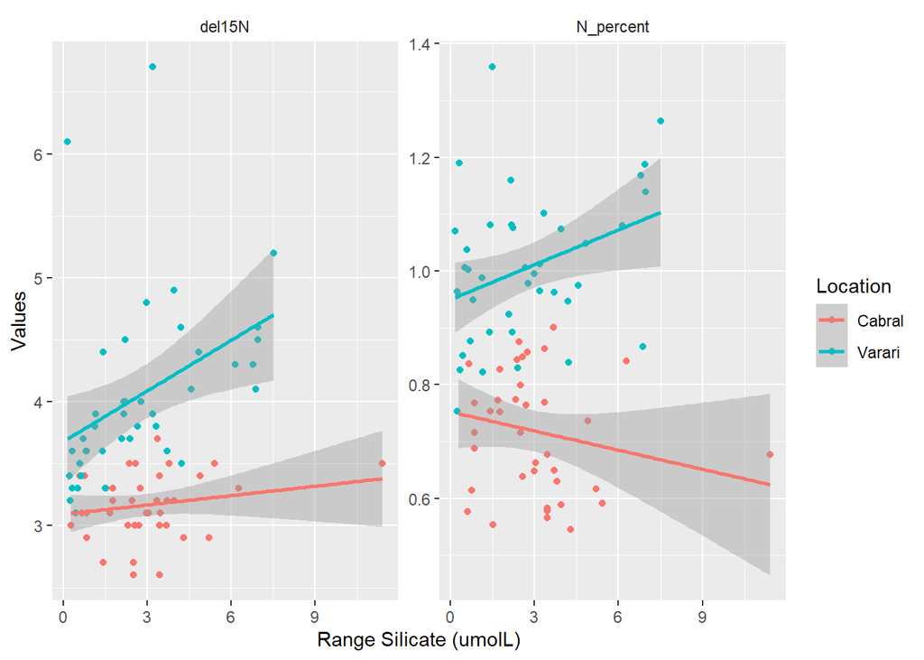

```r
## first check linear relationships with silicate
Full_data %>%
  select(Location, Season, CowTagID, Silicate_umolL, del15N, N_percent) %>%
  pivot_longer(cols = c(del15N:N_percent), names_to = "Parameters", values_to = "Values") %>%
  filter(CowTagID != "VSEEP" & CowTagID != "CSEEP") %>%
  #filter(Silicate_umolL < 15) %>% # for now remove C2 and seep silicate data
  ggplot(aes(x = Silicate_umolL,
             y = Values,
             color = Location
             )) +
  geom_point() +
  geom_smooth(method = "lm") +
  labs(x = "Range Silicate (umolL)") +
  facet_wrap(~Parameters, scales = "free") +
  theme(strip.background = element_rect(fill = "white"))
```

%N ~ Silicate

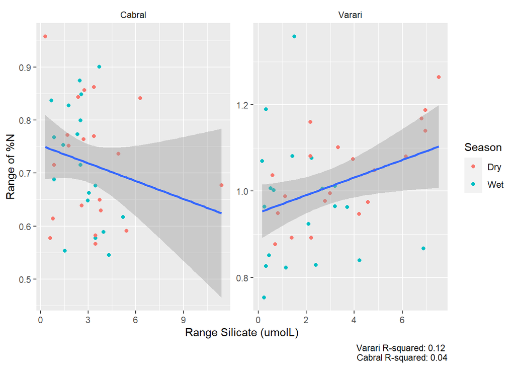

```r
## N_percent ~ Silicate
# linear model of %N with respect to silicate
Vdata <- Full_data %>%
  filter(Location == "Varari") %>%
  filter(CowTagID != "VSEEP")
Vmodel <- lm(data = Vdata, N_percent ~ Silicate_umolL)
Cdata <- Full_data %>%
  filter(Location == "Cabral") %>%
  filter(CowTagID != "CSEEP")
Cmodel <- lm(data = Cdata, N_percent ~ Silicate_umolL)

# display r squared values for lm
Vsum <- summary(Vmodel)$r.squared
Csum <- summary(Cmodel)$r.squared

# graph relationsip
Full_data %>%
  filter(CowTagID != "VSEEP" & CowTagID != "CSEEP") %>%
  ggplot(aes(x=Silicate_umolL,
             y = N_percent,
             group = Location)) +
  geom_point(aes(color = Season)) +
  geom_smooth(method = "lm") +
  labs(caption = paste("Varari R-squared:",round(Vsum, 2), "\n",
                       "Cabral R-squared:", round(Csum, 2)),
       x = "Range Silicate (umolL)",
       y = "Range of %N") +
  facet_wrap(~Location, scales = "free") +
  theme(strip.background = element_rect(fill = "white"))
```

del15N ~ Silicate

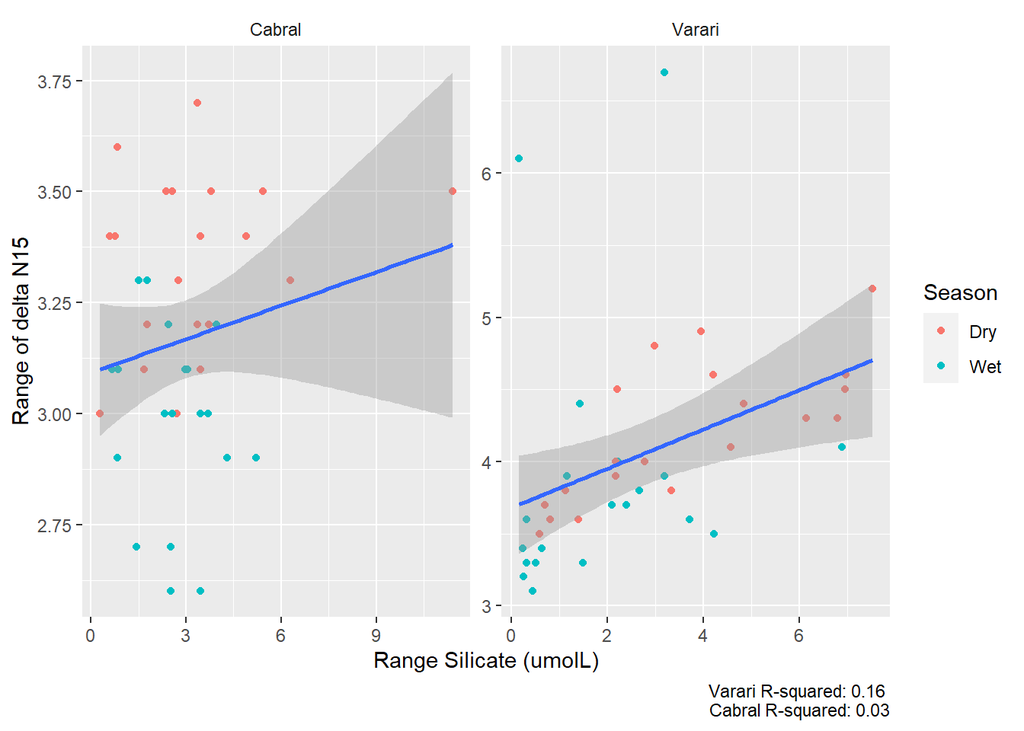

```r
## del15N ~ Silicate
# linear model of del15N with respect to silicate
Vdata <- Full_data %>%
  filter(Location == "Varari") %>%
  filter(CowTagID != "VSEEP")
Vmodel <- lm(data = Vdata, del15N ~ Silicate_umolL)
Cdata <- Full_data %>%
  filter(Location == "Cabral") %>%
  filter(CowTagID != "CSEEP")
Cmodel <- lm(data = Cdata, del15N ~ Silicate_umolL)

# display r squared values for lm
Vsum <- summary(Vmodel)$r.squared
Csum <- summary(Cmodel)$r.squared

# graph relationship
Full_data %>%
  filter(CowTagID != "VSEEP" & CowTagID != "CSEEP") %>%
  ggplot(aes(x=Silicate_umolL,
             y = del15N,
             group = Location)) +
  geom_point(aes(color = Season)) +
  geom_smooth(method = "lm") +
  labs(caption = paste("Varari R-squared:",round(Vsum, 2), "\n",
                       "Cabral R-squared:", round(Csum, 2)),
       x = "Range Silicate (umolL)",
       y = "Range of delta N15") +
  facet_wrap(~Location, scales = "free")+
  theme(strip.background = element_rect(fill = "white"))
```

# End of modified script. Do not run past here.

## Test for normality

## Transform and scale data

- ln transform left-skewed data
- square root transform right-skewed data

Test for normality

Scale the data (and maybe center it?)

## Prepare for Clustering

Taking from the VarSelLCM.R script

Separate data for Varari and Cabral locations

Indicate the number of cores you want to use for parallelization

## Clustering

This section performs a clustering analysis of the *biogeochemistry and* **Turbinaria ornata** *nutrient* data set.

*Warning the univariate margin distribution are defined by class of the features: numeric columns imply Gaussian distributions, integer columns imply Poisson distribution while factor (or ordered) columns imply multinomial distribution*

Clustering is performed with or without variable selection. Model selection is done with BIC because the number of observations is large (compared to the number of features).

Partition near 0 indicates that the clusters are very related to the factor we related the matrix to. Can compare other factors in the future (ie. bacteria communities or coral counts, etc.)

To obtained the partition and the probabilities of classification

## Discriminative Power Barplots

Distribution of the most discriminative variable per clusters

## Empirical vs Theoretical distributions (quick check for good fit)

Example empirical and theoretical distributions of the most discriminative variable (to check that the distribution is well-fitted)

Distribution of a categorical variable per clusters (when we have categorical)

To have details about the selected model

To print the parameters

## Graph

Add site locations to cluster value df

### Create Base Maps for Varari and Cabral

### Show basemaps

## Show clusters on maps

*Triangles showing seepage points*

Save maps together

## Boxplots showing driving factors

## PCA for clustering

## scores plot

## loadings plot

# Turbinaria ornata clustering

## Run clusters again only using *Turbinaria ornata* data to check clusters against full biogeochemical swath

## Clustering

This section performs a clustering analysis of the *biogeochemistry and* **Turbinaria ornata** *nutrient* data set.

*Warning the univariate margin distribution are defined by class of the features: numeric columns imply Gaussian distributions, integer columns imply Poisson distribution while factor (or ordered) columns imply multinomial distribution*

Clustering is performed with or without variable selection. Model selection is done with BIC because the number of observations is large (compared to the number of features).

To obtained the partition and the probabilities of classification

## Discriminative Power Barplots

Distribution of the most discriminative variable per clusters

## Empirical vs Theoretical distributions (quick check for good fit)

Example empirical and theoretical distributions of the most discriminative variable (to check that the distribution is well-fitted)

## Graph

Add site locations to cluster value df

## Show clusters on maps

## Boxplots showing driving factors